# Ch 10: Tibbles

Notes

Functions and packages

- package **tibble**
- `as_tibble`, `tibble`
- **TODO** inverse of `tibble::enframe`

## Creating Tibbles

Why might we want to create non-syntactic variable names? Since variable names are often used as in plots (e.g. axis-titles) or headers in tables, where having spaces or other characters that are invalid R variable names is useful. Those functions will have ways to use text other than the column.

## Tibbles vs. data.frame

Discuss the definition of a data frame.

What is the traditional R `data.frame`?

In general, discuss how this “dialect” of R relates to base R and other R that they will see.

Also, need to discuss types of variables.

```r
nycflights13::flights %>%
  print(n = 10, width = Inf)
```

| year | month | day | dep_time | sched_dep_time | dep_delay | arr_time | sched_arr_time | arr_delay | carrier | flight | tailnum | origin | dest | air_time | distance | hour | minute | time_hour |
| --- | --- | --- | --- | --- | --- | --- | --- | --- | --- | --- | --- | --- | --- | --- | --- | --- | --- | --- |
| 2013 | 1 | 1 | 517 | 515 | 2 | 830 | 819 | 11 | UA | 1545 | N14228 | EWR | IAH | 227 | 1400 | 5 | 15 | 2013-01-01 05:00:00 |
| 2013 | 1 | 1 | 533 | 529 | 4 | 850 | 830 | 20 | UA | 1714 | N24211 | LGA | IAH | 227 | 1416 | 5 | 29 | 2013-01-01 05:00:00 |
| 2013 | 1 | 1 | 542 | 540 | 2 | 923 | 850 | 33 | AA | 1141 | N619AA | JFK | MIA | 160 | 1089 | 5 | 40 | 2013-01-01 05:00:00 |
| 2013 | 1 | 1 | 544 | 545 | -1 | 1004 | 1022 | -18 | B6 | 725 | N804JB | JFK | BQN | 183 | 1576 | 5 | 45 | 2013-01-01 05:00:00 |
| 2013 | 1 | 1 | 554 | 600 | -6 | 812 | 837 | -25 | DL | 461 | N668DN | LGA | ATL | 116 | 762 | 6 | 0 | 2013-01-01 06:00:00 |
| 2013 | 1 | 1 | 554 | 558 | -4 | 740 | 728 | 12 | UA | 1696 | N39463 | EWR | ORD | 150 | 719 | 5 | 58 | 2013-01-01 05:00:00 |
| 2013 | 1 | 1 | 555 | 600 | -5 | 913 | 854 | 19 | B6 | 507 | N516JB | EWR | FLL | 158 | 1065 | 6 | 0 | 2013-01-01 06:00:00 |
| 2013 | 1 | 1 | 557 | 600 | -3 | 709 | 723 | -14 | EV | 5708 | N829AS | LGA | IAD | 53 | 229 | 6 | 0 | 2013-01-01 06:00:00 |
| 2013 | 1 | 1 | 557 | 600 | -3 | 838 | 846 | -8 | B6 | 79 | N593JB | JFK | MCO | 140 | 944 | 6 | 0 | 2013-01-01 06:00:00 |
| 2013 | 1 | 1 | 558 | 600 | -2 | 753 | 745 | 8 | AA | 301 | N3ALAA | LGA | ORD | 138 | 733 | 6 | 0 | 2013-01-01 06:00:00 |

[output cut: 990 more lines]

If this were printed in the console it would be much worse

```r
as.data.frame(nycflights13::flights)
```

### Subsetting

- **Note** Warnings about partial matching! What is it and why is it dangerous.

```r
df <- tibble(x = runif(5), y = rnorm(5))
df$x
```

```
[1] 0.65418411 0.02598058 0.90048081 0.16349198 0.87289130
```

```r
df[["x"]]
```

```
[1] 0.65418411 0.02598058 0.90048081 0.16349198 0.87289130
```

```r
df[[1]]
```

```
[1] 0.65418411 0.02598058 0.90048081 0.16349198 0.87289130
```

```r
df %>% .$x
```

```
[1] 0.65418411 0.02598058 0.90048081 0.16349198 0.87289130
```

```r
df %>% .[["x"]]
```

```
[1] 0.65418411 0.02598058 0.90048081 0.16349198 0.87289130
```

## Interacting with older code

**Note** Not all older functions work with tibbles (an example is Amelia); usually because they rely on quirks in `data.frame` behavior that `tibbles` “fix”. Use `as.data.frame()` to turn a tibble back into a `data.frame`. This is usually because of `[` and the way it inconsistenly returns a vector or a data frame. With tibbles `[` always returns a data frame

### Exercises

1. How can you tell if an object is a tibble? (Hint: try printing `mtcars`, which is a regular data frame).

```r
mtcars
```

|  | mpg | cyl | disp | hp | drat | wt | qsec | vs | am | gear | carb |
| --- | --- | --- | --- | --- | --- | --- | --- | --- | --- | --- | --- |
| Mazda RX4 | 21.0 | 6 | 160.0 | 110 | 3.90 | 2.620 | 16.46 | 0 | 1 | 4 | 4 |
| Mazda RX4 Wag | 21.0 | 6 | 160.0 | 110 | 3.90 | 2.875 | 17.02 | 0 | 1 | 4 | 4 |
| Datsun 710 | 22.8 | 4 | 108.0 | 93 | 3.85 | 2.320 | 18.61 | 1 | 1 | 4 | 1 |
| Hornet 4 Drive | 21.4 | 6 | 258.0 | 110 | 3.08 | 3.215 | 19.44 | 1 | 0 | 3 | 1 |
| Hornet Sportabout | 18.7 | 8 | 360.0 | 175 | 3.15 | 3.440 | 17.02 | 0 | 0 | 3 | 2 |
| Valiant | 18.1 | 6 | 225.0 | 105 | 2.76 | 3.460 | 20.22 | 1 | 0 | 3 | 1 |
| Duster 360 | 14.3 | 8 | 360.0 | 245 | 3.21 | 3.570 | 15.84 | 0 | 0 | 3 | 4 |
| Merc 240D | 24.4 | 4 | 146.7 | 62 | 3.69 | 3.190 | 20.00 | 1 | 0 | 4 | 2 |
| Merc 230 | 22.8 | 4 | 140.8 | 95 | 3.92 | 3.150 | 22.90 | 1 | 0 | 4 | 2 |
| Merc 280 | 19.2 | 6 | 167.6 | 123 | 3.92 | 3.440 | 18.30 | 1 | 0 | 4 | 4 |

[output cut: 22 more lines]

```r
class(mtcars)
```

```
[1] "data.frame"
```

```r
class(as_tibble(mtcars))
```

```
[1] "tbl_df"     "tbl"        "data.frame"
```

Tibbles will only print out a limited number of rows and show the class on top of each column. Addtionally, tibbles have class `"tbl_df"` and `"tbl_"` in addition to `"data.frame"`.

2. Compare and contrast the following operations on a `data.frame` and equivalent tibble. What is different? Why might the default data frame behaviours cause you frustration?

```r
df <- data.frame(abc = 1, xyz = "a")
df$x
```

```
[1] a
Levels: a
```

```r
df[, "xyz"]
```

```
[1] a
Levels: a
```

```r
df[, c("abc", "xyz")]
```

| abc | xyz |
| --- | --- |
| 1 | a |

```r
tbl <- as_tibble(df)
tbl$x
```

```
Unknown column 'x'
```

```r
tbl[, "xyz"]
```

| xyz |
| --- |
| a |

```r
tbl[, c("abc", "xyz")]
```

| abc | xyz |
| --- | --- |
| 1 | a |

Using `$` a data.frame will partially complete the column. So even though we wrote `df$x` it returned `df$xyz`. This saves a few keystrokes, but can result in accidentally using a different variable than you thought you were using.

With data.frames, with `[` the type of object that is returned differs on the number of columns. If it is one column, it won’t return a data.frame, but instead will return a vector. With more than one column, then it will return a data.frame. This is fine if you know what you are passing in, but suppose you did `df[ , vars]` where `vars` was a variable. Then you what that code does depends on `length(vars)` and you’d have to write code to account for those situations or risk bugs.

3. If you have the name of a variable stored in an object, e.g. `var <- "mpg"`, how can you extract the reference variable from a tibble?

You can use the double bracket, like `df[[var]]`. You cannot use the dollar sign, becuase `df$var` would look for a column named `var`.

4. Practice referring to non-syntactic names in the following data frame by:
5. Extracting the variable called 1.
6. Plotting a scatterplot of 1 vs 2.
7. Creating a new column called 3 which is 2 divided by 1.
8. Renaming the columns to one, two and three.

```r
annoying <- tibble(
  `1` = 1:10,
  `2` = `1` * 2 + rnorm(length(`1`))
)
```

Extract the variable called 1:

```r
annoying[["1"]]
```

```
 [1]  1  2  3  4  5  6  7  8  9 10
```

or

```r
annoying$`1`
```

```
 [1]  1  2  3  4  5  6  7  8  9 10
```

A scatterplot of `1` vs. `2`:

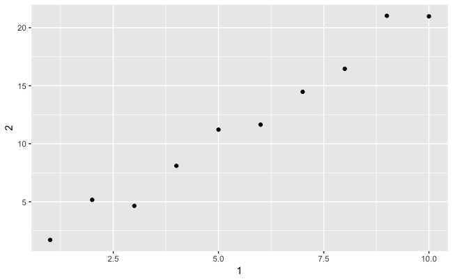

```r
ggplot(annoying, aes(x = `1`, y = `2`)) +
  geom_point()
```

A new column `3` with is `2` divided by `1`:

```r
annoying[["3"]] = annoying$`2` / annoying$`1`
```

Renaming the columns to `one`, `two`, and `three`:

```r
annoying <- rename(annoying, one = `1`, two = `2`, three = `3`)
glimpse(annoying)
```

```
Observations: 10
Variables: 3
$ one   <int> 1, 2, 3, 4, 5, 6, 7, 8, 9, 10
$ two   <dbl> 1.714081, 5.165673, 4.646910, 8.097483, 11.216687, 11.643516, ...
$ three <dbl> 1.714081, 2.582836, 1.548970, 2.024371, 2.243337, 1.940586, 2....
```

5. What does `tibble::enframe()` do? When might you use it?

It converts named vectors to a data frame with names and values

```r
?tibble::enframe
```

6. What option controls how many additional column names are printed at the footer of a tibble?

The print function for tibbles is in `print.tbl_df`:

```r
?print.tbl_df
```

The option `n_extra` determines the number of extra columns to print information for.